# AnVIL Setup

## Setup on AnVIL

1. You need to sign into Terra with your Google account. This is the only way you can launch applications and perform computations on AnVIL. Launch AnVIL at https://anvil.terra.bio/, and you should be prompted to sign in with your Google account.

[figure not shown]

## Setup on AnVIL

⚠️ Make sure you provide your Google login information to the instructor! ⚠️

## Setup on AnVIL

Go to the Class Workspace at https://anvil.terra.bio/#workspaces/data-wrangling-workshop/SISBID-data-wrangling-2022

[figure not shown]

## Clone the Workspace

Click on the teardrop button and select “Clone”.

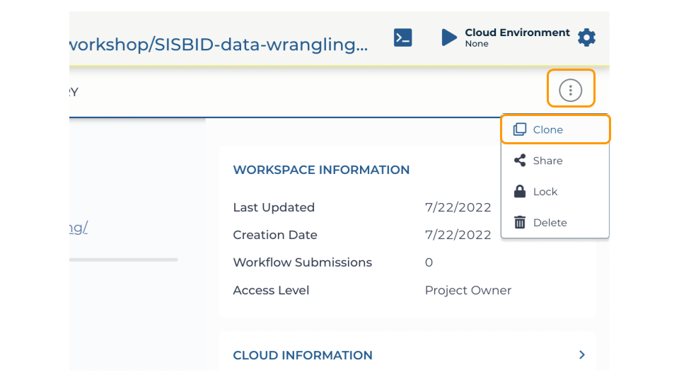

## Clone the Workspace

Name your Workspace (use your name!) and select the “SISBID-Wrangling-2022-student” billing project.

[figure not shown]

## Launch RStudio

Once in your newly cloned Workspace, you can launch the cloud instance! Click on “Cloud Environment” on the top right.

[figure not shown]

## Launch RStudio

Click “CUSTOMIZE”.

[figure not shown]

## Launch RStudio

From the “Application configuration” menu, select “RStudio 4.2.0, Bioconductor 3.15, Python 3.8.10”.

[figure not shown]

## Launch RStudio

Click “CREATE”. Your Cloud Environment will take a few minutes to spin up.

[figure not shown]

## Open RStudio

Click on “OPEN RSTUDIO” when the environment is ready.

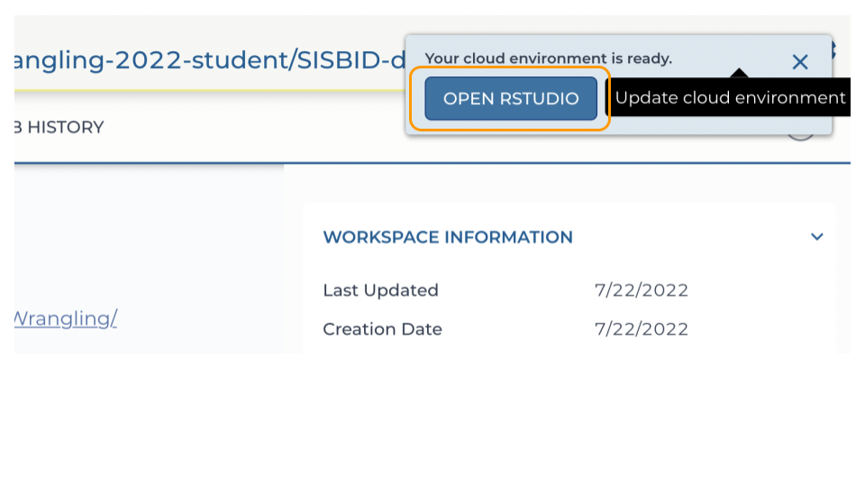

## Create the Project

Once in RStudio, select the “New Project” button.

[figure not shown]

## Create the Project

Select “Version Control”.

[figure not shown]

## Create the Project

Enter the URL : https://github.com/SISBID/Data-Wrangling. Make sure the Project is a subdirectory of `~`. Click “Create Project”.

[figure not shown]

## Create the Project

You should now see files listed in your workspace (including some datasets we’ll be using). Feel free to change any files here - they are yours now! For the most up-to-date versions of files, please visit the website: http://sisbid.github.io/Data-Wrangling/.

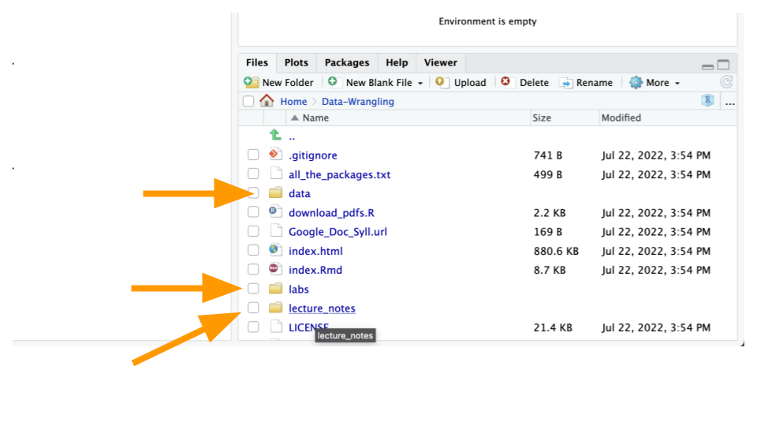

## Pause the Environment

It’s very important to stop your cloud environment when you are done so you don’t accumulate too many charges. Between class sessions, you can click the pause button on the top right. This frees up resources for others!

[figure not shown]